# 3_GradientBoosting

2023-02-03

## Stochastic Gradient Boosting

### Tunning de gradient boosting

Se realiza un primer tunning del algoritmo gradient boosting con caret, probando los parametros basicos de *shrinkage*, *n.minobsinnode* y *n.trees* mas las variables seleccionadas con *stepwise*

```
##    n.trees interaction.depth shrinkage n.minobsinnode
## 51    1000                 2       0.1              5
```

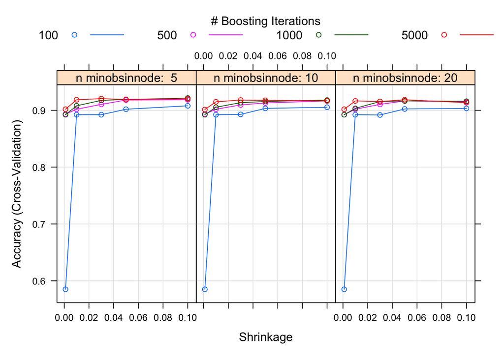

```r
set.seed(12345)
# El shrinkage va desde los valores 0.0001 y 0.2
# Cuanto mas alto mas rapido pero puede resultar menos fino
# n.minobsnode mide la complejidad
# interaction.depth = c(2) arboles binarios

gb_grid <- expand_grid(
    shrinkage = c(0.1, 0.05, 0.03, 0.01, 0.001),
    n.minobsinnode = c(5,10,20),
    n.trees = c(100,500,1000,5000),
    interaction.depth = c(2))

control_gb <- trainControl(
    method = "cv",
    number = 4,
    savePredictions = "all",
    classProbs = TRUE)

gbm <- train(
    factor(varObjBin) ~ h10pix + temp90 + trees + trees90 + Ymin + Ymax + temp +
    humid + humid90,
    data = dengue,
    method = "gbm",
    trControl = control_gb,
    tuneGrid = gb_grid,
    distribution = "bernoulli",
    bag.fraction = 1,
    verbose = FALSE)

plot(gbm)
gbm$bestTune
```

**Observaciones:**

- Segun gbm$bestTune los mejores resultados se consiguen con 1000 iteraciones, shrinkage de 0.1 y n.minobsinnode de 5. Los graficos muestran que en iteraciones desde 500 en adelante no se observan diferencias considerables y tienen a compartir resultados especialmente desde el shrinkage 0.06. El maximo accuracy estaria entre 0.06 y 0.10 de shrinkage ademas de minobsinnode 5 tal como lo indica bestTune.

#### Estudio de early stopping

Se prueba con algunos parametros para buscar en que iteracion se estabiliza el algoritmo

```
##   n.trees interaction.depth shrinkage n.minobsinnode
## 9    5000                 2       0.1              5
```

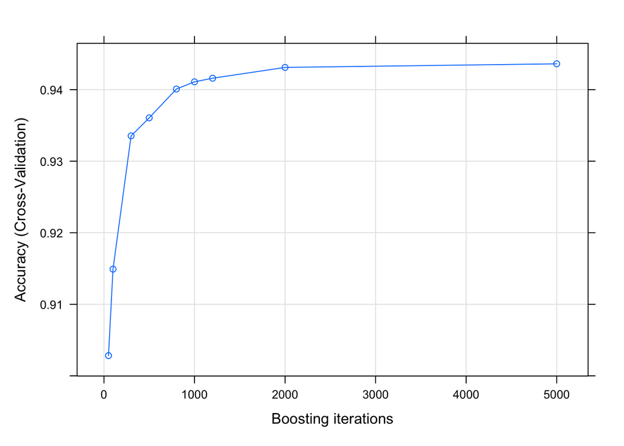

```r
# Tuneado early stopping, se cambia bag.fraction por 0.5 en vez de 1
gbmgrid <- expand.grid(
    shrinkage = c(0.1),
    n.minobsinnode = c(5),
    n.trees = c(50, 100, 300, 500, 800, 1000, 1200, 2000, 5000),
    interaction.depth = c(2))

gbm2 <- train(
    factor(varObjBin) ~h10pix + temp90 + trees + trees90 + Ymin + Ymax + temp +
        humid + humid90,
    data = dengue,
    method = "gbm",
    trControl = control_gb,
    tuneGrid = gbmgrid,
    distribution = "bernoulli",
    bag.fraction = 0.5,
    verbose = FALSE)

gbm2$bestTune
plot(gbm2, xlab = "Boosting iterations")

# Importancia variables
# summary(gbm2)
tabla <- summary(gbm2)
par(cex=1.5, las =2)
barplot(tabla$rel.inf, names.arg = row.names(tabla), col = "#F5E1FD",
        main = "Importancia de variables - gradient boosting")
```

Importancia de variables

[figure not shown]

**Observaciones:**

- Pendiente, preguntar si se usan todas las variables o las seleccionadas con stepwise

### Validacion cruzada para gradient boosting

Se genera la validación cruzada para gradient boosting utilizando los parametros obtenidos en el proceso anterior de tunning:

```r
# 2.Validacion cruzada repetida gradient -----------------------------------------
# Segun el grafico entre 2000 y 5000 no hay tanta diferencia, se deja en 3000
medias12 <- cruzadagbmbin(
    data = dengue,
    vardep="varObjBin",
    listconti=c("h10pix", "temp90", "trees", "trees90", "Ymin", "Ymax",
    "temp", "humid", "humid90"),
    listclass = c(""),
    grupos = 4,
    sinicio = 1234,
    repe = 5,
    n.minobsinnode = 5,
    shrinkage = 0.1,
    n.trees = 3000,
    interaction.depth = 2)

medias12$modelo <- "gbm"
```

### Comparacion de medias y boxplot

Utilizando la función genera_gráficos() se generan los gráficos para realizar comparación de medias y evaluar los modelos

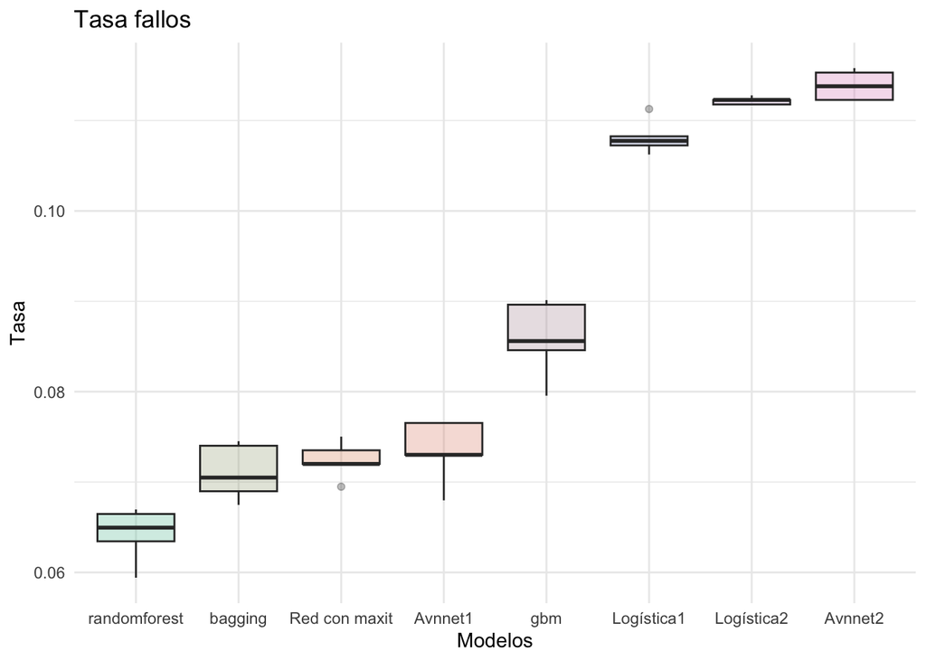

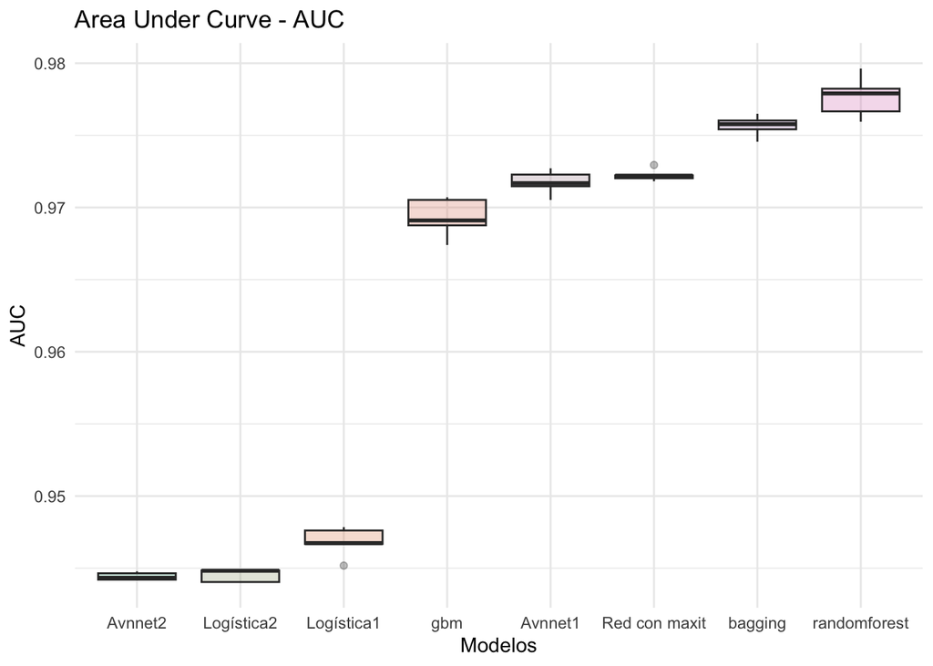

```r
genera_graficos(medias1, medias2, medias3, medias4, medias5,medias6, medias11,
                medias12)
```

Observaciones:

- gbm() tiene un buen auc y esta en el medio del grafico de la tasa de fallos, de todas maneras no alcanza los niveles que muestra un random forest o un bagging para este dataset.

## Xgboost

### Tunning de Xgboost

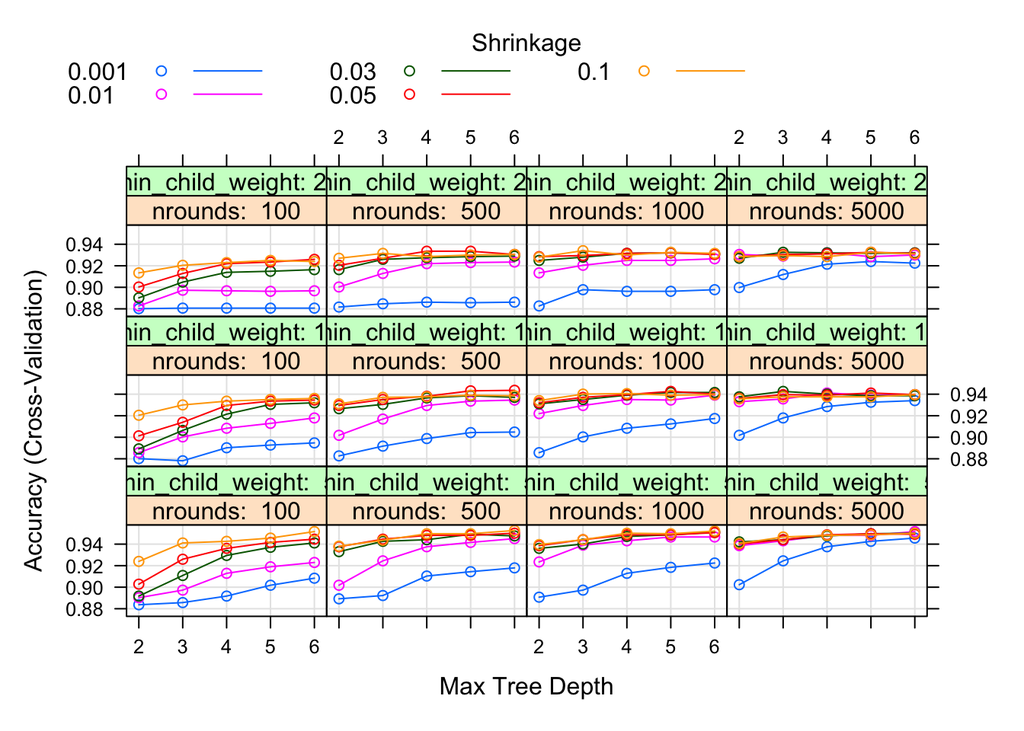

|  | nrounds | max_depth | eta | gamma | colsample_bytree | min_child_weight | subsample |
| --- | --- | --- | --- | --- | --- | --- | --- |
| 290 | 500 | 6 | 0.1 | 0 | 1 | 5 | 1 |

```r
## 3. Tuneo Xgboost --------------------------------------------------------
set.seed(12345)
xgbmgrid <- expand.grid(
    min_child_weight = c(5, 10, 20),
    eta = c(0.1, 0.05, 0.03, 0.01, 0.001),
    nrounds = c(100, 500, 1000, 5000),
    max_depth = c(2, 3, 4, 5, 6),
    gamma = 0,
    colsample_bytree = 1,
    subsample = 1)

control_xgboost <-trainControl(
    method = "cv",
    number = 4,
    savePredictions = "all",
    classProbs = TRUE)

xgbm <- train(
    factor(varObjBin) ~.,
    data = dengue,
    method = "xgbTree",
    trControl = control_xgboost,
    tuneGrid = xgbmgrid,
    verbose = FALSE,
    verbosity = 0)


plot(xgbm)
xgbm$bestTune
```

Observaciones:

- Pendiente, es necesario hacer feature selection?

#### Estudio de early stopping con xgboost

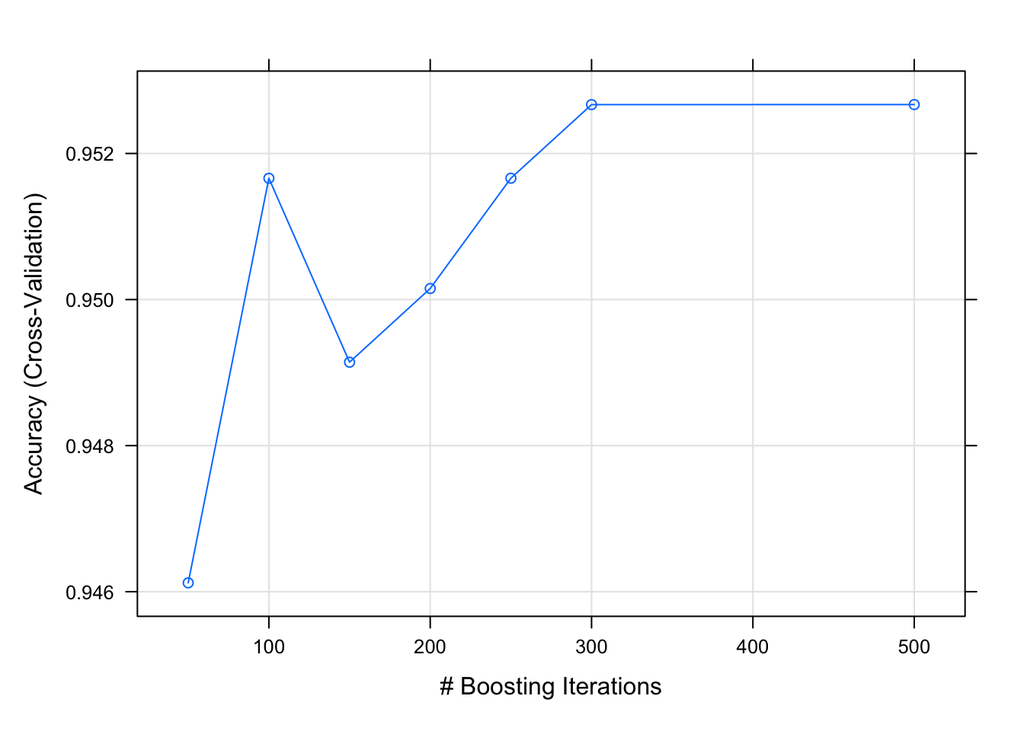

[figure not shown]

|  | nrounds | max_depth | eta | gamma | colsample_bytree | min_child_weight | subsample |
| --- | --- | --- | --- | --- | --- | --- | --- |
| 7 | 500 | 6 | 0.1 | 0 | 1 | 5 | 1 |

[output not shown]

```r
# Early stopping
# Con los parametros entregados anteriormente en best tune
xgbmgrid2 <- expand.grid(
    eta = c(0.1),
    min_child_weight = c(5),
    nrounds = c(50, 100, 150, 200, 250, 300, 500),
    max_depth = 6,
    gamma = 0,
    colsample_bytree = 1,
    subsample = 1)

set.seed(12345)
control_xgboost1 <-trainControl(
    method = "cv",
    number = 4,
    savePredictions = "all",
    classProbs = TRUE)

xgbm2 <- train(
    factor(varObjBin) ~.,
    data = dengue,
    method = "xgbTree",
    trControl = control_xgboost1,
    tuneGrid = xgbmgrid2,
    verbose = FALSE)

plot(xgbm2)

# Se cambia la semilla para observaer variaciones
set.seed(45673)
control_xgboost2 <-trainControl(
    method = "cv",
    number = 4,
    savePredictions = "all",
    classProbs = TRUE)

xgbm3 <- train(
    factor(varObjBin) ~.,
    data = dengue,
    method = "xgbTree",
    trControl = control_xgboost2,
    tuneGrid = xgbmgrid2,
    verbose=FALSE)

xgbm3$bestTune
plot(xgbm3)

# Importancia de variables
varImp(xgbm3)
plot(varImp(xgbm3))
```

```r
# Solo con las variables seleccionadas en stepwise
xgbmgrid3 <- expand.grid(
    eta = c(0.1, 0.05, 0.03, 0.01, 0.001),
    min_child_weight = c(5, 10, 20),
    nrounds = c(50,100,150,200,250,300),
    max_depth = c(2,3,4,5,6), gamma = 0,
    colsample_bytree = 1,
    subsample = 1)

set.seed(12345)
xgbm4 <- train(
    factor(varObjBin) ~ h10pix + h10pix90 + Xmax + humid90 +
    Ymax + temp90 + Xmin,
    data = dengue,
    method = "xgbTree",
    trControl = control_xgboost,
    tuneGrid = xgbmgrid3,
    verbose = FALSE)

xgbm4$bestTune
plot(xgbm4)
```

[output not shown]

### Comparacion de medias y boxplot

Utilizando la función genera_gráficos() se generan los gráficos para realizar comparación de medias y evaluar los modelos

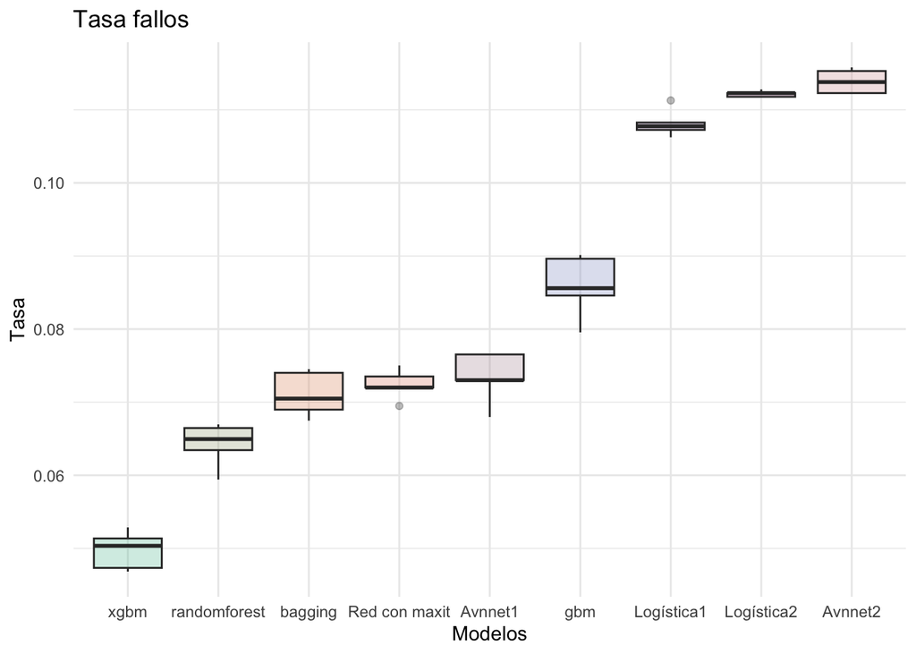

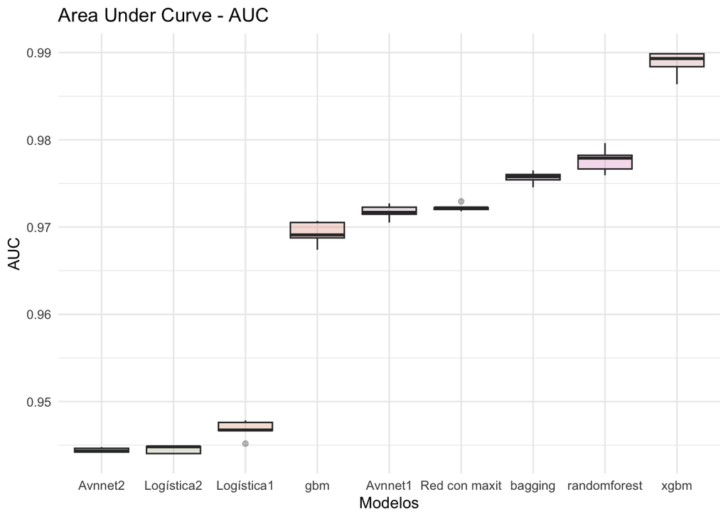

```r
genera_graficos(medias1, medias2, medias3, medias4, medias5,medias6, medias11,
                medias12, medias13)
```